# Zotero group IAS

Published

16 October 2026

Zotero data of 16 October 2026 · IPBES Literature Report 0.4.0 · [source code on GitHub](https://github.com/IPBES-Data/IPBES.LiteratureReport)

This report shows the state of the Zotero group **IAS** ([open the group in Zotero](https://www.zotero.org/groups/2352922)). It gives an overview of the literature in the group, and lists the items which should be corrected.

Each item in the lists can be opened in the Zotero **web** library or in the Zotero **app** on your computer, so that it can be corrected directly. Corrected items disappear from the lists the next time the report is updated. Some checks compare the items with [OpenAlex](https://openalex.org), an open catalogue of scholarly publications.

## Summary

| Status | Check | Items |
| --- | --- | --- |
| ● Please fix | Retracted publications | 1 |
| ● Please fix | DOI points to a different publication | 133 |
| ● Please fix | Items which are in the group more than once | 7 |
| ● Please fix | DOI field with an invalid DOI | 3 |
| ● Please fix | DOI field with a link or prefix instead of the DOI | 208 |
| ● Please check | ISSN not in the standard form | 776 |
| ● Please check | DOI in the wrong field | 85 |
| ● Please check | DOI not found in OpenAlex | 63 |
| ● Please check | Missing or unusual publication year | 19 |
| ● Please check | Empty journal, volume, issue or pages, found in OpenAlex | 116 |
| ● Please check | Language not given as a language code | 282 |
| ● Please check | Items without DOI, ISBN, ISSN or URL | 122 |
| ● Please check | Items without DOI, for which OpenAlex has one | 428 |
| ● OK | OpenAlex ID in Extra not valid | 0 |
| ● For information | Items without their OpenAlex ID in Extra | 3921 |
| ● For information | Items without tags | 19 |

**Please fix**: these items contain errors. **Please check**: these items may need a correction. **For information**: no action needed unless the group uses this, e.g. tags.

## Items to fix

The lists are sorted by importance. Use the search field above a list to find an item. **web** opens the item in the Zotero web library, **app** in the Zotero app.

### Retracted publications

These publications have been retracted. Check whether they should still be cited, and mark or remove them in Zotero.

| Open in Zotero | Title | DOI |
| --- | --- | --- |
| <a href="https://www.zotero.org/groups/2352922/items/LABYQWTN" target="_blank">web</a> &middot; <a href="zotero://select/groups/2352922/items/LABYQWTN">app</a> | RETRACTED ARTICLE: Origin and cross-species transmission of bat coronaviruses in China | <a href="https://doi.org/10.1038/s41467-020-17687-3" target="_blank">10.1038/s41467-020-17687-3</a> |

### DOI points to a different publication

The DOI of these items leads to a publication with a different title or year. Usually the DOI is wrong: open the DOI to see where it leads, and correct it in Zotero. Differences of one year (e.g. published online before print) are not listed.

| Open in Zotero | Title in Zotero | Year in Zotero | The DOI leads to | Its year | DOI |
| --- | --- | --- | --- | --- | --- |
| <a href="https://www.zotero.org/groups/2352922/items/36NKRZYZ" target="_blank">web</a> &middot; <a href="zotero://select/groups/2352922/items/36NKRZYZ">app</a> | Exotic Earthworm Invasions in North America: Ecological and Policy Implications: Expanding global commerce may be increasing the likelihood of exotic earthworm invasions, which could have negative imp… | 2002 | Exotic Earthworm Invasions in North America: Ecological and Policy Implications | 2002 | <a href="https://doi.org/10.1641/0006-3568(2002)052[0801:eeiina]2.0.co;2" target="_blank">10.1641/0006-3568(2002)052[0801:eeiina]2.0.co;2</a> |
| <a href="https://www.zotero.org/groups/2352922/items/L8TQM7WU" target="_blank">web</a> &middot; <a href="zotero://select/groups/2352922/items/L8TQM7WU">app</a> | Extreme climatic events change the dynamics and invasibility of semi-arid annual plant communities: Extreme events and plant invasibility | 2011 | Extreme climatic events change the dynamics and invasibility of semi-arid annual plant communities | 2011 | <a href="https://doi.org/10.1111/j.1461-0248.2011.01693.x" target="_blank">10.1111/j.1461-0248.2011.01693.x</a> |
| <a href="https://www.zotero.org/groups/2352922/items/Y9WKMZXW" target="_blank">web</a> &middot; <a href="zotero://select/groups/2352922/items/Y9WKMZXW">app</a> | The potential global distribution of the invasive weed <i>Nassella neesiana</i> under current and future climates | 2012 | The potential global distribution of the invasive weed Nassella neesiana under current and future climates | 2010 | <a href="https://doi.org/10.1007/s10530-010-9905-6" target="_blank">10.1007/s10530-010-9905-6</a> |
| <a href="https://www.zotero.org/groups/2352922/items/TPWW8Z5B" target="_blank">web</a> &middot; <a href="zotero://select/groups/2352922/items/TPWW8Z5B">app</a> | Anthropogenically induced adaptation to invade (AIAI): contemporary adaptation to human-altered habitats within the native range can promote invasions: Anthropogenically induced adaptation to invade | 2012 | Anthropogenically induced adaptation to invade (AIAI): contemporary adaptation to human‐altered habitats within the native range can promote invasions | 2011 | <a href="https://doi.org/10.1111/j.1752-4571.2011.00211.x" target="_blank">10.1111/j.1752-4571.2011.00211.x</a> |
| <a href="https://www.zotero.org/groups/2352922/items/9AI95ZE9" target="_blank">web</a> &middot; <a href="zotero://select/groups/2352922/items/9AI95ZE9">app</a> | An inclusive approach to assesse nature's contributions to people | 2018 | Assessing nature's contributions to people | 2018 | <a href="https://doi.org/10.1126/science.aap8826" target="_blank">10.1126/science.aap8826</a> |
| <a href="https://www.zotero.org/groups/2352922/items/UJ6GZG4X" target="_blank">web</a> &middot; <a href="zotero://select/groups/2352922/items/UJ6GZG4X">app</a> | Trees and shrubs as invasive alien species - a global review: Global review of invasive trees & shrubs | 2011 | Trees and shrubs as invasive alien species – a global review | 2011 | <a href="https://doi.org/10.1111/j.1472-4642.2011.00782.x" target="_blank">10.1111/j.1472-4642.2011.00782.x</a> |
| <a href="https://www.zotero.org/groups/2352922/items/4WE24WKD" target="_blank">web</a> &middot; <a href="zotero://select/groups/2352922/items/4WE24WKD">app</a> | Introduction to Conservation Genetics | 2010 | Introduction to Conservation Genetics | 2002 | <a href="https://doi.org/10.1017/cbo9780511808999" target="_blank">10.1017/cbo9780511808999</a> |
| <a href="https://www.zotero.org/groups/2352922/items/VLENENBG" target="_blank">web</a> &middot; <a href="zotero://select/groups/2352922/items/VLENENBG">app</a> | Emerald ash borer, black ash, and Native American basketmaking: Invasive insects, forest ecosystems, and cultural practices | 2017 | Biodiversity, Conservation, and Environmental Management in the Great Lakes Basin | 2017 | <a href="https://doi.org/10.4324/9781315268774" target="_blank">10.4324/9781315268774</a> |
| <a href="https://www.zotero.org/groups/2352922/items/B3LRTRM8" target="_blank">web</a> &middot; <a href="zotero://select/groups/2352922/items/B3LRTRM8">app</a> | Maximizing the Policy Impacts of Public Engagement: A European Study | 2015 | Maximizing the Policy Impacts of Public Engagement | 2014 | <a href="https://doi.org/10.1177/0162243914550319" target="_blank">10.1177/0162243914550319</a> |
| <a href="https://www.zotero.org/groups/2352922/items/VTYEIHHY" target="_blank">web</a> &middot; <a href="zotero://select/groups/2352922/items/VTYEIHHY">app</a> | Developing a framework for responsible innovation | 2020 | Developing a framework for responsible innovation | 2013 | <a href="https://doi.org/10.1016/j.respol.2013.05.008" target="_blank">10.1016/j.respol.2013.05.008</a> |

[output cut: 123 more lines]

### Items which are in the group more than once

These items are in the group more than once, with the same DOI, or with the same title, year and first author. Keep one copy and merge or delete the others, e.g. with *Duplicate Items* in the Zotero app.

| Open in Zotero | Title | Copies |
| --- | --- | --- |
| <a href="https://www.zotero.org/groups/2352922/items/XKKAU2IV" target="_blank">web</a> &middot; <a href="zotero://select/groups/2352922/items/XKKAU2IV">app</a><br><a href="https://www.zotero.org/group… | Chapter Six - A Vision for Global Biodiversity Monitoring With Citizen Science | 2 |
| <a href="https://www.zotero.org/groups/2352922/items/QGMXF3TN" target="_blank">web</a> &middot; <a href="zotero://select/groups/2352922/items/QGMXF3TN">app</a><br><a href="https://www.zotero.org/group… | Plant invasions in protected areas: patterns, problems and challenges | 2 |
| <a href="https://www.zotero.org/groups/2352922/items/K5U3QNCX" target="_blank">web</a> &middot; <a href="zotero://select/groups/2352922/items/K5U3QNCX">app</a><br><a href="https://www.zotero.org/group… | Invasive species removals and scale – contrasting island and mainland experience | 2 |
| <a href="https://www.zotero.org/groups/2352922/items/R5FACPNY" target="_blank">web</a> &middot; <a href="zotero://select/groups/2352922/items/R5FACPNY">app</a><br><a href="https://www.zotero.org/group… | A Handbook of Global Freshwater Invasive Species | 2 |
| <a href="https://www.zotero.org/groups/2352922/items/DNQGDYCT" target="_blank">web</a> &middot; <a href="zotero://select/groups/2352922/items/DNQGDYCT">app</a><br><a href="https://www.zotero.org/group… | Lessons from old fenced plots: Eco‐cultural Impacts of feral ungulates and potential decline in sea‐level rise resilience of coastal floodplains in northern Australia | 2 |
| <a href="https://www.zotero.org/groups/2352922/items/BDWIGJLS" target="_blank">web</a> &middot; <a href="zotero://select/groups/2352922/items/BDWIGJLS">app</a><br><a href="https://www.zotero.org/group… | Encyclopedia of Biological Invasions | 2 |
| <a href="https://www.zotero.org/groups/2352922/items/BW28LAD5" target="_blank">web</a> &middot; <a href="zotero://select/groups/2352922/items/BW28LAD5">app</a><br><a href="https://www.zotero.org/group… | Invasive alien mammals of European Union concern | 2 |

### DOI field with an invalid DOI

The DOI field of these items contains something which is not a valid DOI. Correct or remove it.

| Open in Zotero | Title | Content of the DOI field |
| --- | --- | --- |
| <a href="https://www.zotero.org/groups/2352922/items/GNG7XTF6" target="_blank">web</a> &middot; <a href="zotero://select/groups/2352922/items/GNG7XTF6">app</a> | Novel ecosystems: implications for conservation and restoration | https://www.sciencedirect.com/science/article/abs/pii/S0169534709002018 |
| <a href="https://www.zotero.org/groups/2352922/items/ABXB2YE3" target="_blank">web</a> &middot; <a href="zotero://select/groups/2352922/items/ABXB2YE3">app</a> | Plastic pollution in the world's oceans: more than 5 trillion plastic pieces weighing over 250,000 tons afloat at sea | 10.1371/ journal.pone.0111913 |
| <a href="https://www.zotero.org/groups/2352922/items/FYJYPZ7I" target="_blank">web</a> &middot; <a href="zotero://select/groups/2352922/items/FYJYPZ7I">app</a> | Biological Invasions by Exotic Grasses, the Grass/Fire Cycle, and Global Change | annurev.es.23.110192.000431 |

### DOI field with a link or prefix instead of the DOI

The DOI field of these items contains the DOI as a link (`https://doi.org/…`) or with a prefix (`DOI …`). Citation styles add the link themselves, so it would appear twice. Replace it with the DOI only.

| Open in Zotero | Title | Content of the DOI field | DOI |
| --- | --- | --- | --- |
| <a href="https://www.zotero.org/groups/2352922/items/4JHQ9XWE" target="_blank">web</a> &middot; <a href="zotero://select/groups/2352922/items/4JHQ9XWE">app</a> | Disturbance, invasion and re-invasion: managing the weed-shaped hole in disturbed ecosystems | https://doi.org/10.1111/j.1461-0248.2007.01067.x | <a href="https://doi.org/10.1111/j.1461-0248.2007.01067.x" target="_blank">10.1111/j.1461-0248.2007.01067.x</a> |
| <a href="https://www.zotero.org/groups/2352922/items/GYGADVID" target="_blank">web</a> &middot; <a href="zotero://select/groups/2352922/items/GYGADVID">app</a> | Homing and movement patterns of a South African limpet <i>Scutellastra argenvillei</i> in an area invaded by an alien mussel <i>Mytilus galloprovincialis</i> | http://dx.doi.org/10.3354/meps243111 | <a href="https://doi.org/10.3354/meps243111" target="_blank">10.3354/meps243111</a> |
| <a href="https://www.zotero.org/groups/2352922/items/EECUYPAW" target="_blank">web</a> &middot; <a href="zotero://select/groups/2352922/items/EECUYPAW">app</a> | The eBird enterprise: an integrated approach to development and application of citizen science | https://doi.org/10.1016/j.biocon.2013.11.003 | <a href="https://doi.org/10.1016/j.biocon.2013.11.003" target="_blank">10.1016/j.biocon.2013.11.003</a> |
| <a href="https://www.zotero.org/groups/2352922/items/33P9295H" target="_blank">web</a> &middot; <a href="zotero://select/groups/2352922/items/33P9295H">app</a> | A Global Bio-Prospecting Regime: Partnership or Piracy? | https://doi.org/10.2307/40203478 | <a href="https://doi.org/10.2307/40203478" target="_blank">10.2307/40203478</a> |
| <a href="https://www.zotero.org/groups/2352922/items/YMQJX4SW" target="_blank">web</a> &middot; <a href="zotero://select/groups/2352922/items/YMQJX4SW">app</a> | History, applications and methodological issues and perspectives for the use of environmental DNA (eDNA) in marine and freshwater environments | https://doi.org/10.15517/rbt.v62i4.13231 | <a href="https://doi.org/10.15517/rbt.v62i4.13231" target="_blank">10.15517/rbt.v62i4.13231</a> |
| <a href="https://www.zotero.org/groups/2352922/items/ELAF7FIV" target="_blank">web</a> &middot; <a href="zotero://select/groups/2352922/items/ELAF7FIV">app</a> | Global guidelines for the sustainable use of non-native trees to prevent tree invasions and mitigate their negative impacts | https://doi.org/10.3897/neobiota.61.58380 | <a href="https://doi.org/10.3897/neobiota.61.58380" target="_blank">10.3897/neobiota.61.58380</a> |
| <a href="https://www.zotero.org/groups/2352922/items/8D9H2WHY" target="_blank">web</a> &middot; <a href="zotero://select/groups/2352922/items/8D9H2WHY">app</a> | The significance of the sub-Antarctic Kerguelen Islands for the assessment of the vulnerability of native communities to climate change, alien insect invasions and plant viruses | https://doi.org/10.1007/s10530-011-9946-5 | <a href="https://doi.org/10.1007/s10530-011-9946-5" target="_blank">10.1007/s10530-011-9946-5</a> |
| <a href="https://www.zotero.org/groups/2352922/items/3MWGCWSD" target="_blank">web</a> &middot; <a href="zotero://select/groups/2352922/items/3MWGCWSD">app</a> | Integrative environmental governance: enhancing governance in the era of synergies | https://doi.org/10.1016/j.cosust.2015.05.008 | <a href="https://doi.org/10.1016/j.cosust.2015.05.008" target="_blank">10.1016/j.cosust.2015.05.008</a> |
| <a href="https://www.zotero.org/groups/2352922/items/RDSZSNGU" target="_blank">web</a> &middot; <a href="zotero://select/groups/2352922/items/RDSZSNGU">app</a> | Coping with the wicked problem of climate adaptation across scales: The Five R Governance Capabilities | http://dx.doi.org/10.1016/j.landurbplan.2016.01.007 | <a href="https://doi.org/10.1016/j.landurbplan.2016.01.007" target="_blank">10.1016/j.landurbplan.2016.01.007</a> |
| <a href="https://www.zotero.org/groups/2352922/items/DRNCYUQ5" target="_blank">web</a> &middot; <a href="zotero://select/groups/2352922/items/DRNCYUQ5">app</a> | Predicting potential distributions of invasive species: where to go from here? | https://doi.org/10.1111/j.1472-4642.2010.00652.x | <a href="https://doi.org/10.1111/j.1472-4642.2010.00652.x" target="_blank">10.1111/j.1472-4642.2010.00652.x</a> |

[output cut: 198 more lines]

### ISSN not in the standard form

The ISSN field of these items is not in the standard form `1234-567X` (several separated by “,”), or contains something which is not a valid ISSN, e.g. an ISBN.

| Open in Zotero | Title | Content of the ISSN field | Standard form | Not a valid ISSN |
| --- | --- | --- | --- | --- |
| <a href="https://www.zotero.org/groups/2352922/items/ZNBRV4GV" target="_blank">web</a> &middot; <a href="zotero://select/groups/2352922/items/ZNBRV4GV">app</a> | Management feasibility of established invasive plant species in Queensland, Australia: A stakeholders’ perspective | 03014797 | 0301-4797 | NA |
| <a href="https://www.zotero.org/groups/2352922/items/M9L9HDD2" target="_blank">web</a> &middot; <a href="zotero://select/groups/2352922/items/M9L9HDD2">app</a> | Altitudinal distribution of alien plant species in the Swiss Alps | 14338319 | 1433-8319 | NA |
| <a href="https://www.zotero.org/groups/2352922/items/2SS7E6UP" target="_blank">web</a> &middot; <a href="zotero://select/groups/2352922/items/2SS7E6UP">app</a> | Global Urban Land-Use Trends and Climate Impacts | 18773435 | 1877-3435 | NA |
| <a href="https://www.zotero.org/groups/2352922/items/MZ4X58WM" target="_blank">web</a> &middot; <a href="zotero://select/groups/2352922/items/MZ4X58WM">app</a> | Projecting future expansion of invasive species: comparing and improving methodologies for species distribution modeling | 13541013 | 1354-1013 | NA |
| <a href="https://www.zotero.org/groups/2352922/items/97PD86I2" target="_blank">web</a> &middot; <a href="zotero://select/groups/2352922/items/97PD86I2">app</a> | Predicting the rate of range expansion of an invasive alien bumblebee (<i>Bombus terrestris</i>) using a stochastic spatio-temporal model | 00063207 | 0006-3207 | NA |
| <a href="https://www.zotero.org/groups/2352922/items/VGKH3DS3" target="_blank">web</a> &middot; <a href="zotero://select/groups/2352922/items/VGKH3DS3">app</a> | The Importance of Parasite Geography and Spillover Effects for Global Patterns of Host-Parasite Associations in Two Invasive Species | 13669516 | 1366-9516 | NA |
| <a href="https://www.zotero.org/groups/2352922/items/97FCPCNM" target="_blank">web</a> &middot; <a href="zotero://select/groups/2352922/items/97FCPCNM">app</a> | Managing for Change: Wetland Transitions under Sea-Level Rise and Outcomes for Threatened Species | 13669516 | 1366-9516 | NA |
| <a href="https://www.zotero.org/groups/2352922/items/V3D9DLRF" target="_blank">web</a> &middot; <a href="zotero://select/groups/2352922/items/V3D9DLRF">app</a> | Invasion hotspots for non-native plants in Australia under current and future climates | 13541013 | 1354-1013 | NA |
| <a href="https://www.zotero.org/groups/2352922/items/L8TQM7WU" target="_blank">web</a> &middot; <a href="zotero://select/groups/2352922/items/L8TQM7WU">app</a> | Extreme climatic events change the dynamics and invasibility of semi-arid annual plant communities: Extreme events and plant invasibility | 1461023X | 1461-023X | NA |
| <a href="https://www.zotero.org/groups/2352922/items/ALQBKUJG" target="_blank">web</a> &middot; <a href="zotero://select/groups/2352922/items/ALQBKUJG">app</a> | Increased Invasive Potential of Non-Native <i>Phragmites australis</i> : Elevated CO<sub>2</sub> and Temperature Alleviate Salinity Effects on Photosynthesis and Growth | 13541013 | 1354-1013 | NA |

[output cut: 766 more lines]

### DOI in the wrong field

These items have no DOI in the DOI field, but a DOI in the URL or Extra field. Copy the DOI into the DOI field.

| Open in Zotero | Title | DOI in URL | DOI in Extra |
| --- | --- | --- | --- |
| <a href="https://www.zotero.org/groups/2352922/items/8TUTJSMS" target="_blank">web</a> &middot; <a href="zotero://select/groups/2352922/items/8TUTJSMS">app</a> | Citizen scientist and marine research: volunteers participatns, their contribbutions, and projection for the future | <a href="https://doi.org/10.1201/b17143-6" target="_blank">10.1201/b17143-6</a> |  |
| <a href="https://www.zotero.org/groups/2352922/items/MCAXFX3N" target="_blank">web</a> &middot; <a href="zotero://select/groups/2352922/items/MCAXFX3N">app</a> | Many tongues, one people: The making of Tharu identity in Nepal | <a href="https://doi.org/10.7591/j.ctv3s8mfn" target="_blank">10.7591/j.ctv3s8mfn</a> |  |
| <a href="https://www.zotero.org/groups/2352922/items/2RQ6CLTS" target="_blank">web</a> &middot; <a href="zotero://select/groups/2352922/items/2RQ6CLTS">app</a> | Towards an early warning and information system for invasive alien species (IAS) threatening biodiversity in Europe |  | <a href="https://doi.org/10.2800/4167" target="_blank">10.2800/4167</a> |
| <a href="https://www.zotero.org/groups/2352922/items/SEY8PFQ5" target="_blank">web</a> &middot; <a href="zotero://select/groups/2352922/items/SEY8PFQ5">app</a> | Reforming the WTO – Towards a sustainable and effective multilateral trading system | <a href="https://doi.org/10.2781/272480" target="_blank">10.2781/272480</a> |  |
| <a href="https://www.zotero.org/groups/2352922/items/M9EDKFVV" target="_blank">web</a> &middot; <a href="zotero://select/groups/2352922/items/M9EDKFVV">app</a> | Changing coasts: marine aliens and artificial structures | <a href="https://doi.org/10.1201/b12157-6/changing-coasts-marine-aliens-arti" target="_blank">10.1201/b12157-6/changing-coasts-marine-aliens-arti</a> |  |
| <a href="https://www.zotero.org/groups/2352922/items/DEHK6HQZ" target="_blank">web</a> &middot; <a href="zotero://select/groups/2352922/items/DEHK6HQZ">app</a> | Assessing biodiversity in Europe : the 2010 report | <a href="https://doi.org/10.2800/42824" target="_blank">10.2800/42824</a> |  |
| <a href="https://www.zotero.org/groups/2352922/items/PILBW3JL" target="_blank">web</a> &middot; <a href="zotero://select/groups/2352922/items/PILBW3JL">app</a> | Biosecurity, invasive species and the law. | <a href="https://doi.org/10.4324/9781315530857-6/biosecurity-invasive-species-law-opi-outhwaite" target="_blank">10.4324/9781315530857-6/biosecurity-invasive-species-law-opi-outhwaite</a> |  |
| <a href="https://www.zotero.org/groups/2352922/items/T5JCBADV" target="_blank">web</a> &middot; <a href="zotero://select/groups/2352922/items/T5JCBADV">app</a> | Aliens on the Move: Transportation Networks and Non-native Species | <a href="https://doi.org/10.1007/978-3-319-57496-7_5" target="_blank">10.1007/978-3-319-57496-7_5</a> |  |
| <a href="https://www.zotero.org/groups/2352922/items/V4SMHNQQ" target="_blank">web</a> &middot; <a href="zotero://select/groups/2352922/items/V4SMHNQQ">app</a> | Human Environment Interactions: The invasion of <i>Prosopis juliflora</i> in the Drylands of Northeast Ethiopia | <a href="https://doi.org/10.3197/9781912186310.ch15" target="_blank">10.3197/9781912186310.ch15</a> |  |
| <a href="https://www.zotero.org/groups/2352922/items/ZK7XSM3H" target="_blank">web</a> &middot; <a href="zotero://select/groups/2352922/items/ZK7XSM3H">app</a> | Classical Biological Control of <i>Mikania micrantha</i>: the Sustainable Solution |  | <a href="https://doi.org/10.1079/9781780646275.0162" target="_blank">10.1079/9781780646275.0162</a> |

[output cut: 75 more lines]

### DOI not found in OpenAlex

These DOIs were not found in OpenAlex. The DOI may be wrong: open it to check. If it leads to the right publication, the publication is simply not (yet) in OpenAlex and nothing needs to be done.

| Open in Zotero | Title | DOI |
| --- | --- | --- |
| <a href="https://www.zotero.org/groups/2352922/items/MIBPMHP5" target="_blank">web</a> &middot; <a href="zotero://select/groups/2352922/items/MIBPMHP5">app</a> | The methodological assessment report on scenarios and models of biodiversity and ecosystem services | <a href="https://doi.org/10.5281/zenodo.3235428" target="_blank">10.5281/zenodo.3235428</a> |
| <a href="https://www.zotero.org/groups/2352922/items/DWTD6BY8" target="_blank">web</a> &middot; <a href="zotero://select/groups/2352922/items/DWTD6BY8">app</a> | The IPBES regional assessment report on biodiversity and ecosystem services for the Americas | <a href="https://doi.org/10.5281/zenodo.3236253" target="_blank">10.5281/zenodo.3236253</a> |
| <a href="https://www.zotero.org/groups/2352922/items/9UE7GB3P" target="_blank">web</a> &middot; <a href="zotero://select/groups/2352922/items/9UE7GB3P">app</a> | Best Practices for Publishing Biodiversity Data from Environmental Impact Assessments. Version 1.0. | <a href="https://doi.org/10.35035/doc-5xdm-8762" target="_blank">10.35035/doc-5xdm-8762</a> |
| <a href="https://www.zotero.org/groups/2352922/items/JBFNEE9E" target="_blank">web</a> &middot; <a href="zotero://select/groups/2352922/items/JBFNEE9E">app</a> | Natural capital: from metaphor to measurement | <a href="https://doi.org/10.1086/6760341" target="_blank">10.1086/6760341</a> |
| <a href="https://www.zotero.org/groups/2352922/items/K3AD9KRG" target="_blank">web</a> &middot; <a href="zotero://select/groups/2352922/items/K3AD9KRG">app</a> | Management of sediments through stakeholder involvement - The risks and value of engaging stakeholders when looking for solutions for sediment-related problems | <a href="https://doi.org/10.1065/jss2004.10.121" target="_blank">10.1065/jss2004.10.121</a> |
| <a href="https://www.zotero.org/groups/2352922/items/RHL9NQPR" target="_blank">web</a> &middot; <a href="zotero://select/groups/2352922/items/RHL9NQPR">app</a> | Data from: Corruption, development and governance indicators predict invasive species risk from trade | <a href="https://doi.org/10.5061/dryad.1qq64" target="_blank">10.5061/dryad.1qq64</a> |
| <a href="https://www.zotero.org/groups/2352922/items/SH22NZP4" target="_blank">web</a> &middot; <a href="zotero://select/groups/2352922/items/SH22NZP4">app</a> | The status of biological invasions and their management in South Africa in 2019 | <a href="https://doi.org/10.5281/zenodo.3947613" target="_blank">10.5281/zenodo.3947613</a> |
| <a href="https://www.zotero.org/groups/2352922/items/3MLHJ4IF" target="_blank">web</a> &middot; <a href="zotero://select/groups/2352922/items/3MLHJ4IF">app</a> | Law is order, and good law is good order: The role of governance in the regulation of invasive alien species | <a href="https://doi.org/10.3316/agispt.20121130" target="_blank">10.3316/agispt.20121130</a> |
| <a href="https://www.zotero.org/groups/2352922/items/GMLBRS2S" target="_blank">web</a> &middot; <a href="zotero://select/groups/2352922/items/GMLBRS2S">app</a> | Environmental Stewardship Duties in Biosecurity: Issues and Challenges | <a href="https://doi.org/10.3316/agispt.20181228005297" target="_blank">10.3316/agispt.20181228005297</a> |
| <a href="https://www.zotero.org/groups/2352922/items/ZACZGHZL" target="_blank">web</a> &middot; <a href="zotero://select/groups/2352922/items/ZACZGHZL">app</a> | Global assessment report on biodiversity and ecosystem services of the Intergovernmental Science-Policy Platform on Biodiversity and Ecosystem Services | <a href="https://doi.org/10.5281/zenodo.3831673" target="_blank">10.5281/zenodo.3831673</a> |

[output cut: 53 more lines]

### Missing or unusual publication year

These items have no date, a date from which no year could be read, or a year in the future. Correct the date in Zotero.

| Open in Zotero | Title | Date | Problem | Date in OpenAlex |
| --- | --- | --- | --- | --- |
| <a href="https://www.zotero.org/groups/2352922/items/GCTC6FC8" target="_blank">web</a> &middot; <a href="zotero://select/groups/2352922/items/GCTC6FC8">app</a> |  |  | No date | NA |
| <a href="https://www.zotero.org/groups/2352922/items/Q4DE2EIG" target="_blank">web</a> &middot; <a href="zotero://select/groups/2352922/items/Q4DE2EIG">app</a> |  |  | No date | NA |
| <a href="https://www.zotero.org/groups/2352922/items/U4UHDZBF" target="_blank">web</a> &middot; <a href="zotero://select/groups/2352922/items/U4UHDZBF">app</a> |  |  | No date | NA |
| <a href="https://www.zotero.org/groups/2352922/items/97T963K9" target="_blank">web</a> &middot; <a href="zotero://select/groups/2352922/items/97T963K9">app</a> |  |  | No date | NA |
| <a href="https://www.zotero.org/groups/2352922/items/QQE25IXG" target="_blank">web</a> &middot; <a href="zotero://select/groups/2352922/items/QQE25IXG">app</a> |  |  | No date | NA |
| <a href="https://www.zotero.org/groups/2352922/items/I57UUYDE" target="_blank">web</a> &middot; <a href="zotero://select/groups/2352922/items/I57UUYDE">app</a> |  |  | No date | NA |
| <a href="https://www.zotero.org/groups/2352922/items/GUZI523J" target="_blank">web</a> &middot; <a href="zotero://select/groups/2352922/items/GUZI523J">app</a> |  |  | No date | NA |
| <a href="https://www.zotero.org/groups/2352922/items/GMTQ5IP4" target="_blank">web</a> &middot; <a href="zotero://select/groups/2352922/items/GMTQ5IP4">app</a> |  |  | No date | NA |
| <a href="https://www.zotero.org/groups/2352922/items/3RPXJPTF" target="_blank">web</a> &middot; <a href="zotero://select/groups/2352922/items/3RPXJPTF">app</a> |  |  | No date | NA |
| <a href="https://www.zotero.org/groups/2352922/items/VI6G8EQG" target="_blank">web</a> &middot; <a href="zotero://select/groups/2352922/items/VI6G8EQG">app</a> |  |  | No date | NA |

[output cut: 9 more lines]

### Empty journal, volume, issue or pages, found in OpenAlex

These journal articles have an empty journal, volume, issue or pages field, and OpenAlex has the value for their DOI. Check it with the DOI and fill in the field.

| Open in Zotero | Title | Field | Value in OpenAlex | DOI |
| --- | --- | --- | --- | --- |
| <a href="https://www.zotero.org/groups/2352922/items/CVAZBGLV" target="_blank">web</a> &middot; <a href="zotero://select/groups/2352922/items/CVAZBGLV">app</a> | 'Now it’s not a billabong': eco-cultural assessment of billabong condition in remote northern Australia | Volume | 72 | <a href="https://doi.org/10.1071/mf20080" target="_blank">10.1071/mf20080</a> |
| <a href="https://www.zotero.org/groups/2352922/items/CVAZBGLV" target="_blank">web</a> &middot; <a href="zotero://select/groups/2352922/items/CVAZBGLV">app</a> | 'Now it’s not a billabong': eco-cultural assessment of billabong condition in remote northern Australia | Issue | 7 | <a href="https://doi.org/10.1071/mf20080" target="_blank">10.1071/mf20080</a> |
| <a href="https://www.zotero.org/groups/2352922/items/CVAZBGLV" target="_blank">web</a> &middot; <a href="zotero://select/groups/2352922/items/CVAZBGLV">app</a> | 'Now it’s not a billabong': eco-cultural assessment of billabong condition in remote northern Australia | Pages | 925-941 | <a href="https://doi.org/10.1071/mf20080" target="_blank">10.1071/mf20080</a> |
| <a href="https://www.zotero.org/groups/2352922/items/FD6ALDPF" target="_blank">web</a> &middot; <a href="zotero://select/groups/2352922/items/FD6ALDPF">app</a> | <i>Phragmites australis</i> management in the United States: 40 years of methods and outcomes | Issue | 0 | <a href="https://doi.org/10.1093/aobpla/plu001" target="_blank">10.1093/aobpla/plu001</a> |
| <a href="https://www.zotero.org/groups/2352922/items/QXE4P2AL" target="_blank">web</a> &middot; <a href="zotero://select/groups/2352922/items/QXE4P2AL">app</a> | A case study of soil food web components affected by <i>Fallopia japonica</i> (Polygonaceae) in three natural habitats in Central Europe | Issue | 1 | <a href="https://doi.org/10.21307/jofnem-2019-042" target="_blank">10.21307/jofnem-2019-042</a> |
| <a href="https://www.zotero.org/groups/2352922/items/YZTP539G" target="_blank">web</a> &middot; <a href="zotero://select/groups/2352922/items/YZTP539G">app</a> | A global review of socioeconomic and environmental impacts of ants reveals new insights for risk assessment | Pages | e2577 | <a href="https://doi.org/10.1002/eap.2577" target="_blank">10.1002/eap.2577</a> |
| <a href="https://www.zotero.org/groups/2352922/items/RDLEA3HY" target="_blank">web</a> &middot; <a href="zotero://select/groups/2352922/items/RDLEA3HY">app</a> | A greener Greenland? Climatic potential and long-term constraints on future expansions of trees and shrubs | Pages | 20120479 | <a href="https://doi.org/10.1098/rstb.2012.0479" target="_blank">10.1098/rstb.2012.0479</a> |
| <a href="https://www.zotero.org/groups/2352922/items/R2A449TD" target="_blank">web</a> &middot; <a href="zotero://select/groups/2352922/items/R2A449TD">app</a> | A preliminary report on the distribution of lizards in Qatar | Issue | 373 | <a href="https://doi.org/10.3897/zookeys.373.5994" target="_blank">10.3897/zookeys.373.5994</a> |
| <a href="https://www.zotero.org/groups/2352922/items/WL4W3YCX" target="_blank">web</a> &middot; <a href="zotero://select/groups/2352922/items/WL4W3YCX">app</a> | A reassessment of the foliose Bangiales (Rhodophyta) in the Balearic Islands including the proposed synonymy of <i>Pyropia olivii</i> with <i>Pyropia koreana</i> | Pages | 229-240 | <a href="https://doi.org/10.1515/bot-2013-0003" target="_blank">10.1515/bot-2013-0003</a> |
| <a href="https://www.zotero.org/groups/2352922/items/GMJHYIUR" target="_blank">web</a> &middot; <a href="zotero://select/groups/2352922/items/GMJHYIUR">app</a> | Abandoned Foreigners: is the stage set for exotic pet reptiles to invade Central Europe? | Issue | 2 | <a href="https://doi.org/10.1007/s10531-017-1444-3" target="_blank">10.1007/s10531-017-1444-3</a> |

[output cut: 138 more lines]

### Language not given as a language code

The language of these items is not given as a language code (`en`, `fr`, `en-US`), e.g. as `English` or `eng`. Citation styles only recognise the codes. Where the language was recognised, the code is shown; otherwise look up the code in the [ISO 639-1 list](https://en.wikipedia.org/wiki/List_of_ISO_639_language_codes).

| Open in Zotero | Title | Language | Language code |
| --- | --- | --- | --- |
| <a href="https://www.zotero.org/groups/2352922/items/5HHDLH6I" target="_blank">web</a> &middot; <a href="zotero://select/groups/2352922/items/5HHDLH6I">app</a> | When is eradication of exotic pest plants a realistic goal? | English | en |
| <a href="https://www.zotero.org/groups/2352922/items/CP8GT3IJ" target="_blank">web</a> &middot; <a href="zotero://select/groups/2352922/items/CP8GT3IJ">app</a> | Assessment on peatlands, biodiversity and climate change: Main report. | English | en |
| <a href="https://www.zotero.org/groups/2352922/items/KUIUQK3M" target="_blank">web</a> &middot; <a href="zotero://select/groups/2352922/items/KUIUQK3M">app</a> | Disequilibrium Vegetation Dynamics Under Future Climate Change | English | en |
| <a href="https://www.zotero.org/groups/2352922/items/ALQBKUJG" target="_blank">web</a> &middot; <a href="zotero://select/groups/2352922/items/ALQBKUJG">app</a> | Increased Invasive Potential of Non-Native <i>Phragmites australis</i> : Elevated CO<sub>2</sub> and Temperature Alleviate Salinity Effects on Photosynthesis and Growth | English | en |
| <a href="https://www.zotero.org/groups/2352922/items/G79B2VIA" target="_blank">web</a> &middot; <a href="zotero://select/groups/2352922/items/G79B2VIA">app</a> | Predicted decrease in global climate suitability masks regional complexity of invasive fruit fly species response to climate change | English | en |
| <a href="https://www.zotero.org/groups/2352922/items/DWTD6BY8" target="_blank">web</a> &middot; <a href="zotero://select/groups/2352922/items/DWTD6BY8">app</a> | The IPBES regional assessment report on biodiversity and ecosystem services for the Americas | eng | en |
| <a href="https://www.zotero.org/groups/2352922/items/7GULGBTK" target="_blank">web</a> &middot; <a href="zotero://select/groups/2352922/items/7GULGBTK">app</a> | The Illegal Wildlife Trade Is a Likely Source of Alien Species | English | en |
| <a href="https://www.zotero.org/groups/2352922/items/E9ZSZ84E" target="_blank">web</a> &middot; <a href="zotero://select/groups/2352922/items/E9ZSZ84E">app</a> | State says goodbye to tree-killing pest | English (United States), en-US | NA |
| <a href="https://www.zotero.org/groups/2352922/items/2IRJB3X7" target="_blank">web</a> &middot; <a href="zotero://select/groups/2352922/items/2IRJB3X7">app</a> | The black swan: the impact of the highly improbable | English | en |
| <a href="https://www.zotero.org/groups/2352922/items/VM5U8835" target="_blank">web</a> &middot; <a href="zotero://select/groups/2352922/items/VM5U8835">app</a> | Non-native species in urban environments: patterns, processes, impacts and challenges | English | en |

[output cut: 272 more lines]

### Items without DOI, ISBN, ISSN or URL

Readers cannot easily find these items. Add a DOI, ISBN, ISSN or URL if one exists. Some items, e.g. personal communications, have none.

| Open in Zotero | Title | Type |
| --- | --- | --- |
| <a href="https://www.zotero.org/groups/2352922/items/JVGZNTWE" target="_blank">web</a> &middot; <a href="zotero://select/groups/2352922/items/JVGZNTWE">app</a> | Red Interamericana de Información de Especies Invasoras, Costa Rica | book |
| <a href="https://www.zotero.org/groups/2352922/items/REPG38ZZ" target="_blank">web</a> &middot; <a href="zotero://select/groups/2352922/items/REPG38ZZ">app</a> | Perverse Subsidies and the Implications for Biodiversity: A review of recent findings and the status of policy reforms | conference paper |
| <a href="https://www.zotero.org/groups/2352922/items/VWZTPWSC" target="_blank">web</a> &middot; <a href="zotero://select/groups/2352922/items/VWZTPWSC">app</a> | Turning back the tide of American mink invasion in partnership with communities | presentation |
| <a href="https://www.zotero.org/groups/2352922/items/L7CQCQIQ" target="_blank">web</a> &middot; <a href="zotero://select/groups/2352922/items/L7CQCQIQ">app</a> | Comment: Uist Hedgehogs—Lessons learnt in wildlife management | journal article |
| <a href="https://www.zotero.org/groups/2352922/items/UFPNTGH8" target="_blank">web</a> &middot; <a href="zotero://select/groups/2352922/items/UFPNTGH8">app</a> | Alien plant pathogens in India | journal article |
| <a href="https://www.zotero.org/groups/2352922/items/N4YRGDXQ" target="_blank">web</a> &middot; <a href="zotero://select/groups/2352922/items/N4YRGDXQ">app</a> | The international code of botanical nomenclature (ICBN), the international code of nomenclature for cultivated plants (ICNCP), and the cultigen | journal article |
| <a href="https://www.zotero.org/groups/2352922/items/JWIVKR83" target="_blank">web</a> &middot; <a href="zotero://select/groups/2352922/items/JWIVKR83">app</a> | Estrategia Nacional para la Conservación y Uso Sostenible de la Diversidad Biológica del Uruguay 2016-2020 | report |
| <a href="https://www.zotero.org/groups/2352922/items/5KY8IQNF" target="_blank">web</a> &middot; <a href="zotero://select/groups/2352922/items/5KY8IQNF">app</a> | The Great Britain Invasive Non-native Species Strategy | journal article |
| <a href="https://www.zotero.org/groups/2352922/items/RRDB97XK" target="_blank">web</a> &middot; <a href="zotero://select/groups/2352922/items/RRDB97XK">app</a> | Review of the efficiency and efficacy of existing legal instruments applicable to invasive alien species | report |
| <a href="https://www.zotero.org/groups/2352922/items/UFG2ZXKG" target="_blank">web</a> &middot; <a href="zotero://select/groups/2352922/items/UFG2ZXKG">app</a> | Long-term monitoring at East and West Flower Garden Banks: 2016 annual report | report |

[output cut: 112 more lines]

### Items without DOI, for which OpenAlex has one

OpenAlex was searched by title for items without a DOI (journal articles, books, book sections, reports, conference papers, theses, preprints). The publications found are compared by title, year and first author: a *likely* match agrees in all three, a *possible* match has a similar title, but e.g. a different year or author. Open the DOI to check that it is the same publication, and add the DOI in Zotero.

| Open in Zotero | Title | Year | Author | Found in OpenAlex | Year (OpenAlex) | Author (OpenAlex) | Match | DOI |
| --- | --- | --- | --- | --- | --- | --- | --- | --- |
| <a href="https://www.zotero.org/groups/2352922/items/ALQHAEC3" target="_blank">web</a> &middot; <a href="zotero://select/groups/2352922/items/ALQHAEC3">app</a> | 15/27. Invasive alien species | 2022 | CBD | 15/27. Invasive alien species | 2022 | CBD | likely | <a href="https://doi.org/10.5281/zenodo.18178019" target="_blank">10.5281/zenodo.18178019</a> |
| <a href="https://www.zotero.org/groups/2352922/items/95AEP2XN" target="_blank">web</a> &middot; <a href="zotero://select/groups/2352922/items/95AEP2XN">app</a> | 15/4. Kunming-Montreal Global Biodiversity Framework | 2022 | CBD | 15/4. Kunming-Montreal Global Biodiversity Framework | 2022 | CBD | likely | <a href="https://doi.org/10.5281/zenodo.18177994" target="_blank">10.5281/zenodo.18177994</a> |
| <a href="https://www.zotero.org/groups/2352922/items/TKT37422" target="_blank">web</a> &middot; <a href="zotero://select/groups/2352922/items/TKT37422">app</a> | 15/5. Monitoring framework for the Kunming-Montreal Global Biodiversity Framework | 2022 | CBD | 15/5. Monitoring framework for the Kunming-Montreal Global Biodiversity Framework | 2022 | CBD | likely | <a href="https://doi.org/10.5281/zenodo.18178015" target="_blank">10.5281/zenodo.18178015</a> |
| <a href="https://www.zotero.org/groups/2352922/items/6F7497US" target="_blank">web</a> &middot; <a href="zotero://select/groups/2352922/items/6F7497US">app</a> | 2. The biogeography of avian invasions: History, accident and market trade | 2015 | Cassey, P. | 2. The Biogeography of Avian Invasions: History, Accident and Market Trade | 2015 | Phillip Cassey | likely | <a href="https://doi.org/10.1515/9783110438666-006" target="_blank">10.1515/9783110438666-006</a> |
| <a href="https://www.zotero.org/groups/2352922/items/6F7497US" target="_blank">web</a> &middot; <a href="zotero://select/groups/2352922/items/6F7497US">app</a> | 2. The biogeography of avian invasions: History, accident and market trade | 2015 | Cassey, P. | 2. The biogeography of avian invasions: History, accident and market trade | 2015 | João Canning‐Clode | possible | <a href="https://doi.org/10.5281/zenodo.18167395" target="_blank">10.5281/zenodo.18167395</a> |
| <a href="https://www.zotero.org/groups/2352922/items/GJ8EZP9D" target="_blank">web</a> &middot; <a href="zotero://select/groups/2352922/items/GJ8EZP9D">app</a> | 5 Mediation between Indigenous and Non-Indigenous Knowledge Systems: Another Analysis of “Two-Way” Conservation in Northern Australia | 2021 | Fache, Elodie | 5 Mediation between Indigenous and Non-Indigenous Knowledge Systems: Another Analysis of “Two-Way” Conservation in Northern Australia | 2017 | Élodie Fache | possible | <a href="https://doi.org/10.3138/9781487513764-006" target="_blank">10.3138/9781487513764-006</a> |
| <a href="https://www.zotero.org/groups/2352922/items/MKEG9DTN" target="_blank">web</a> &middot; <a href="zotero://select/groups/2352922/items/MKEG9DTN">app</a> | A brief guide to emerging infectious diseases and zoonoses | 2014 | WHO | A brief guide to emerging infectious diseases and zoonoses | 2014 | WHO | likely | <a href="https://doi.org/10.5281/zenodo.18191753" target="_blank">10.5281/zenodo.18191753</a> |
| <a href="https://www.zotero.org/groups/2352922/items/MKEG9DTN" target="_blank">web</a> &middot; <a href="zotero://select/groups/2352922/items/MKEG9DTN">app</a> | A brief guide to emerging infectious diseases and zoonoses | 2014 | WHO | A brief guide to emerging infectious diseases and zoonoses | 2014 | WHO | likely | <a href="https://doi.org/10.5281/zenodo.18191780" target="_blank">10.5281/zenodo.18191780</a> |
| <a href="https://www.zotero.org/groups/2352922/items/5NTCXGU7" target="_blank">web</a> &middot; <a href="zotero://select/groups/2352922/items/5NTCXGU7">app</a> | A Comparison of Contraceptive Technologies for Feral Horse Management | 1992 | Garrott, Robert A. | A Comparison of Contraceptive Technologies for Feral Horse Management | 1992 | Robert A. Garrott | likely | <a href="https://doi.org/10.5281/zenodo.18178734" target="_blank">10.5281/zenodo.18178734</a> |
| <a href="https://www.zotero.org/groups/2352922/items/7JQE77QH" target="_blank">web</a> &middot; <a href="zotero://select/groups/2352922/items/7JQE77QH">app</a> | A decision-making framework for restoring riparian zones degraded by invasive alien plants in South Africa | 2005 | Holmes, P. M. | A decision-making framework for restoring riparian zones degraded by invasive alien plants in South Africa | 2005 | P.M. Holmes | likely | <a href="https://doi.org/10.5281/zenodo.18179313" target="_blank">10.5281/zenodo.18179313</a> |

[output cut: 604 more lines]

### OpenAlex ID in Extra not valid

The line `OpenAlex: …` in the Extra field of these items is not an OpenAlex ID, is not in OpenAlex (wrong, or the record was merged into another one), or leads to a different publication. Open the item and the OpenAlex record to check, and correct or remove the line.

**✔ Nothing to fix.**

### Items without their OpenAlex ID in Extra

These items were found in OpenAlex by their DOI, but their Extra field has no line `OpenAlex: W…` with the ID of the publication in OpenAlex, or a different one. The ID links the item to OpenAlex. A different ID can come from OpenAlex merging records; open both to check.

| Open in Zotero | Title | OpenAlex ID | ID in Extra | DOI |
| --- | --- | --- | --- | --- |
| <a href="https://www.zotero.org/groups/2352922/items/MEQJRCXF" target="_blank">web</a> &middot; <a href="zotero://select/groups/2352922/items/MEQJRCXF">app</a> | The use of woody biomass for energy production in the EU | W3131170341 | NA | <a href="https://doi.org/10.2760/831621" target="_blank">10.2760/831621</a> |
| <a href="https://www.zotero.org/groups/2352922/items/2KR2XAVL" target="_blank">web</a> &middot; <a href="zotero://select/groups/2352922/items/2KR2XAVL">app</a> | Interactions among ecosystem stressors and their importance in conservation | W2265312118 | NA | <a href="https://doi.org/10.1098/rspb.2015.2592" target="_blank">10.1098/rspb.2015.2592</a> |
| <a href="https://www.zotero.org/groups/2352922/items/4JHQ9XWE" target="_blank">web</a> &middot; <a href="zotero://select/groups/2352922/items/4JHQ9XWE">app</a> | Disturbance, invasion and re-invasion: managing the weed-shaped hole in disturbed ecosystems | W2168216205 | NA | <a href="https://doi.org/10.1111/j.1461-0248.2007.01067.x" target="_blank">10.1111/j.1461-0248.2007.01067.x</a> |
| <a href="https://www.zotero.org/groups/2352922/items/ZNBRV4GV" target="_blank">web</a> &middot; <a href="zotero://select/groups/2352922/items/ZNBRV4GV">app</a> | Management feasibility of established invasive plant species in Queensland, Australia: A stakeholders’ perspective | W2951028024 | NA | <a href="https://doi.org/10.1016/j.jenvman.2019.05.052" target="_blank">10.1016/j.jenvman.2019.05.052</a> |
| <a href="https://www.zotero.org/groups/2352922/items/GRDK59ZT" target="_blank">web</a> &middot; <a href="zotero://select/groups/2352922/items/GRDK59ZT">app</a> | Taxonomic changes and non-native species: An overview of constraints and new challenges for macroinvertebrate-based indices calculation in river ecosystems | W2906834342 | NA | <a href="https://doi.org/10.1016/j.scitotenv.2019.01.008" target="_blank">10.1016/j.scitotenv.2019.01.008</a> |
| <a href="https://www.zotero.org/groups/2352922/items/Y9BWZC8E" target="_blank">web</a> &middot; <a href="zotero://select/groups/2352922/items/Y9BWZC8E">app</a> | Aliens in Antarctica: Assessing transfer of plant propagules by human visitors to reduce invasion risk | W2103149808 | NA | <a href="https://doi.org/10.1016/j.biocon.2014.01.038" target="_blank">10.1016/j.biocon.2014.01.038</a> |
| <a href="https://www.zotero.org/groups/2352922/items/M9L9HDD2" target="_blank">web</a> &middot; <a href="zotero://select/groups/2352922/items/M9L9HDD2">app</a> | Altitudinal distribution of alien plant species in the Swiss Alps | W1966142270 | NA | <a href="https://doi.org/10.1016/j.ppees.2005.09.006" target="_blank">10.1016/j.ppees.2005.09.006</a> |
| <a href="https://www.zotero.org/groups/2352922/items/4J85BTLR" target="_blank">web</a> &middot; <a href="zotero://select/groups/2352922/items/4J85BTLR">app</a> | The Future of the Uplands | W2139980398 | NA | <a href="https://doi.org/10.1016/j.landusepol.2009.09.013" target="_blank">10.1016/j.landusepol.2009.09.013</a> |
| <a href="https://www.zotero.org/groups/2352922/items/L2GMC2GB" target="_blank">web</a> &middot; <a href="zotero://select/groups/2352922/items/L2GMC2GB">app</a> | Strategies for feeding the world more sustainably with organic agriculture | W2766564513 | NA | <a href="https://doi.org/10.1038/s41467-017-01410-w" target="_blank">10.1038/s41467-017-01410-w</a> |
| <a href="https://www.zotero.org/groups/2352922/items/2SS7E6UP" target="_blank">web</a> &middot; <a href="zotero://select/groups/2352922/items/2SS7E6UP">app</a> | Global Urban Land-Use Trends and Climate Impacts | W2095005842 | NA | <a href="https://doi.org/10.1016/j.cosust.2009.07.012" target="_blank">10.1016/j.cosust.2009.07.012</a> |

[output cut: 3911 more lines]

### Items without tags

These items have no tags. This only matters if the group uses tags, e.g. to assign items to chapters.

| Open in Zotero | Title | Type |
| --- | --- | --- |
| <a href="https://www.zotero.org/groups/2352922/items/GCTC6FC8" target="_blank">web</a> &middot; <a href="zotero://select/groups/2352922/items/GCTC6FC8">app</a> |  | annotation |
| <a href="https://www.zotero.org/groups/2352922/items/Q4DE2EIG" target="_blank">web</a> &middot; <a href="zotero://select/groups/2352922/items/Q4DE2EIG">app</a> |  | annotation |
| <a href="https://www.zotero.org/groups/2352922/items/U4UHDZBF" target="_blank">web</a> &middot; <a href="zotero://select/groups/2352922/items/U4UHDZBF">app</a> |  | annotation |
| <a href="https://www.zotero.org/groups/2352922/items/97T963K9" target="_blank">web</a> &middot; <a href="zotero://select/groups/2352922/items/97T963K9">app</a> |  | annotation |
| <a href="https://www.zotero.org/groups/2352922/items/QQE25IXG" target="_blank">web</a> &middot; <a href="zotero://select/groups/2352922/items/QQE25IXG">app</a> |  | annotation |
| <a href="https://www.zotero.org/groups/2352922/items/I57UUYDE" target="_blank">web</a> &middot; <a href="zotero://select/groups/2352922/items/I57UUYDE">app</a> |  | annotation |
| <a href="https://www.zotero.org/groups/2352922/items/GUZI523J" target="_blank">web</a> &middot; <a href="zotero://select/groups/2352922/items/GUZI523J">app</a> |  | annotation |
| <a href="https://www.zotero.org/groups/2352922/items/GMTQ5IP4" target="_blank">web</a> &middot; <a href="zotero://select/groups/2352922/items/GMTQ5IP4">app</a> |  | annotation |
| <a href="https://www.zotero.org/groups/2352922/items/3RPXJPTF" target="_blank">web</a> &middot; <a href="zotero://select/groups/2352922/items/3RPXJPTF">app</a> |  | annotation |
| <a href="https://www.zotero.org/groups/2352922/items/VI6G8EQG" target="_blank">web</a> &middot; <a href="zotero://select/groups/2352922/items/VI6G8EQG">app</a> |  | annotation |

[output cut: 9 more lines]

## The group at a glance

| Figure | Value |
| --- | --- |
| Items in the group | 5251 |
| Items with a valid DOI | 78% |
| DOIs found in OpenAlex | 98% |
| Open access, of the publications found in OpenAlex | 54% |
| Grey literature (reports, theses, web pages, preprints, …) | 8% |
| Items in English | 61% |
| Items without language | 38% |

### Publication years

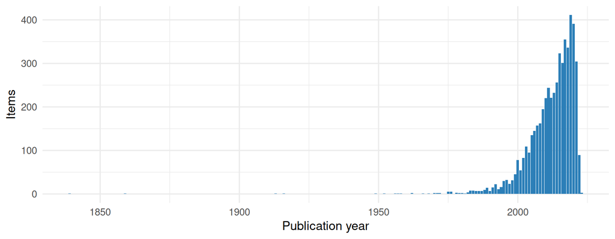

### Types of items

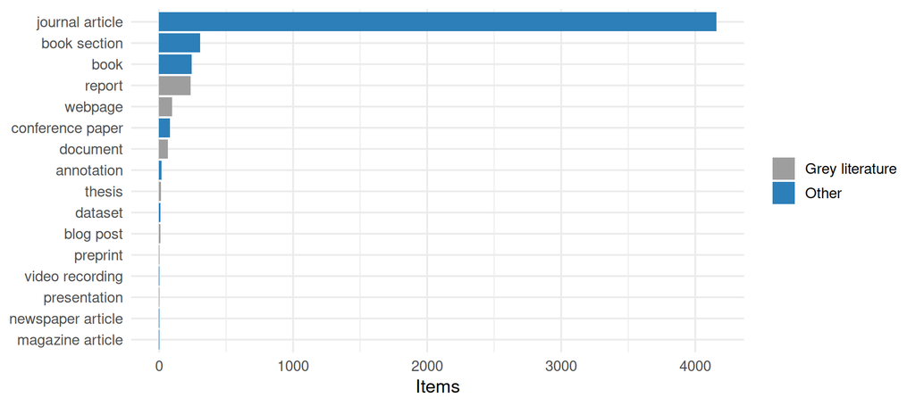

### Open access

Open access status of the publications found in OpenAlex. *Gold* and *diamond*: open in an open access journal; *hybrid*: open in a subscription journal; *green*: an open copy is in a repository; *bronze*: free to read on the publisher’s site; *closed*: not openly available.

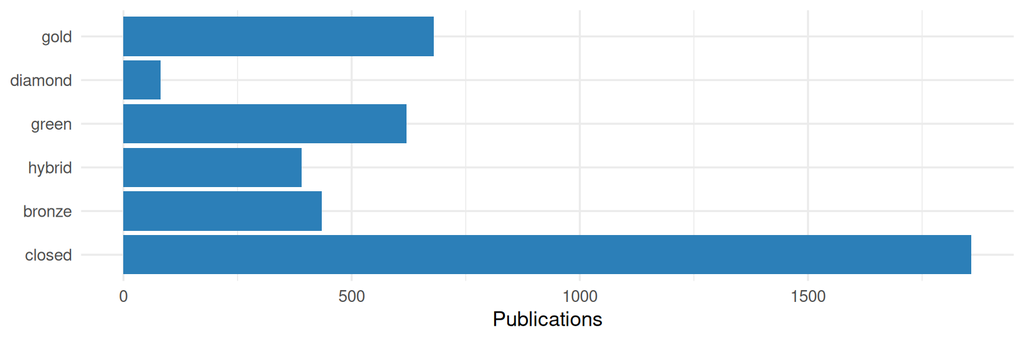

### Most frequent journals

| Journal | Items |
| --- | --- |
| Biological Invasions | 329 |
| NeoBiota | 84 |
| Biological Conservation | 82 |
| Diversity and Distributions | 82 |
| PLoS ONE | 77 |
| Journal of Applied Ecology | 68 |
| Conservation Biology | 59 |
| Frontiers in Ecology and the Environment | 53 |
| Trends in Ecology & Evolution | 51 |
| Ecology Letters | 49 |

### Countries of the authors

Number of publications with at least one author from the country, for the publications found in OpenAlex.

| Country | Publications |
| --- | --- |
| United States | 1432 |
| Australia | 732 |
| United Kingdom | 701 |
| South Africa | 399 |
| Germany | 388 |
| France | 345 |
| Canada | 308 |
| New Zealand | 283 |
| Spain | 251 |
| Italy | 250 |
| Switzerland | 240 |
| Czechia | 204 |
| China | 183 |
| Netherlands | 158 |
| Brazil | 143 |

## How the checks work

**NoteDetails of the checks**

#### identifiers

##### DOI coverage (`met_id_doi`)

Number and share of items with a valid DOI, and items whose DOI field is filled but contains no valid DOI. DOIs are extracted with `openalexPro::extract_doi()` and lower cased.

##### ISBN coverage (`met_id_isbn`)

Number and share of items with an ISBN, overall and for the item types which should have one (`book`, `bookSection`).

##### ISSN coverage (`met_id_issn`)

Number and share of items with an ISSN, overall and for the item types which should have one (`journalArticle`, `magazineArticle`).

##### ISSN not in the standard form (`met_id_issn_form`)

Items whose ISSN field is not in the standard form: each ISSN as `1234-567X` (with hyphen, capital X), several separated by “,”. The ISSNs are checked with their check digit. If all are valid, the standard form is proposed; otherwise the item is listed with the ISSNs which are not valid.

##### DOIs in the wrong field (`met_id_doi_misplaced`)

Items with an empty DOI field but a DOI in the `Url` or `Extra` field. These DOIs are not used for the OpenAlex lookup and should be moved to the DOI field.

##### DOIs in the wrong form (`met_id_doi_form`)

Items whose DOI field contains a valid DOI, but not as a bare DOI: as a link (`https://doi.org/10.…`), with a prefix (`doi:`, `DOI`), URL-encoded (`%5B` for `[`) or with spaces or other characters around it. Citation styles add the link themselves, so a link in the DOI field appears twice in a bibliography. The bare DOI is the one recognised by `openalexPro::extract_doi()`, keeping its upper and lower case.

##### Items without identifier (`met_id_none`)

Items with none of DOI, ISBN, ISSN or Url. These items can neither be checked against OpenAlex nor easily be retrieved by readers.

##### DOIs found in OpenAlex for items without a DOI (`met_id_candidates`)

For items without a DOI, OpenAlex was searched by title (see [get_doi_candidates()]). The works found are compared with the item: title (ignoring case and punctuation), year and the surname of the first author. A work is a *likely* match if the titles are (nearly) the same (similarity at least 0.95), the years differ by at most 1 and the first authors have the same surname (year or author are not compared if the item has none), and the title has at least 4 words (short titles like “Zoonoses” are too general). It is a *possible* match if the titles are similar (at least 0.8). All likely and possible works with a DOI are kept, sorted per item, best first. DOIs used by another item in the group are noted (the item would be a duplicate).

#### metadata

##### Filled fields per item type (`met_meta_fields`)

Percentage of items with a filled field, per item type, for the main fields: Title, Author, Publication Year, Publication Title, Publisher, DOI, ISBN, ISSN, Url, Abstract Note and Language. Not every field is expected for every item type, e.g. reports have no Publication Title.

##### Problematic publication years (`met_meta_year`)

Items whose date is missing (`missing`), from whose date Zotero could not derive a year (`unparseable`), or whose year lies in the future (`future`).

##### Duplicate items (`met_meta_duplicates`)

Items which are in the group more than once, identified by the same DOI, or by the same normalised title (lower case, letters and digits only), publication year and first word of the first author.

##### Language not given as a standard code (`met_meta_language`)

Items whose language is not given as a standard language code, i.e. a two-letter ISO 639-1 code, optionally with a region (`en`, `en-US`), but e.g. as a name (`English`), a three-letter code (`eng`) or in a different spelling (`EN`, `en_us`). Citation styles and other tools only recognise the codes. Where the value is recognised, the standard code is proposed, based on the ISO 639-2 list (R package ISOcodes): codes, three-letter codes and the English names of the languages. Other values, e.g. names in the language itself, several languages or other text, are listed without a proposal.

#### openalex_check

##### Zotero DOIs found in OpenAlex (`met_check_found`)

Valid Zotero DOIs which were / were not found in OpenAlex. A DOI which is not found is either not indexed by OpenAlex or wrong.

##### Retracted works (`met_check_retracted`)

Works flagged as retracted by OpenAlex, with the key of the Zotero item(s) with the same DOI.

##### Wrong DOIs (`met_check_mismatch`)

Items whose DOI points in OpenAlex to a work with a different title or year, which usually means that the wrong DOI is attached to the item. An item is flagged when the title similarity (normalised Levenshtein distance) is below 0.8 or the years differ by more than one.

##### Item type agreement (`met_check_type`)

Zotero item type compared with the OpenAlex work type for items with the same DOI.

##### Missing dates found in OpenAlex (`met_check_date`)

Items without a date whose DOI was found in OpenAlex: the publication date in OpenAlex is proposed. OpenAlex gives 1 January when only the year is known, so such dates are proposed as the year only. Items whose DOI points to a different publication are left out.

##### Empty fields found in OpenAlex (`met_check_fill`)

Journal articles with an empty journal, volume, issue or pages field whose DOI was found in OpenAlex with these details: the values in OpenAlex are proposed. The journal is only taken if the publication is in a journal in OpenAlex (not e.g. a repository). Page ranges which end before they start (e.g. `1260-2`, shortened or wrong) are not proposed. Items whose DOI points to a different publication are left out.

##### OpenAlex ID in the Extra field (`met_check_openalex_id`)

Items whose DOI was found in OpenAlex, compared with the OpenAlex ID noted in their Extra field (a line `OpenAlex: W…`). Items without such a line can get it, which links them to OpenAlex for later checks. Items with a different ID are listed for checking: OpenAlex merges records, and the ID of a merged record redirects to the new one. Items whose DOI points to a different publication are left out.

##### OpenAlex ID in the Extra field not valid (`met_check_extra_id`)

Checks the lines `OpenAlex: …` in the Extra field (looked up by [get_extra_ids()]). A line is not valid if - it is not an OpenAlex work ID (`W` and digits), - the item has several lines with different IDs, - the ID is not in OpenAlex (wrong, or merged into another record), or - the work is a different publication: its DOI is not the DOI of the item, or, for items without DOI, its title is not similar (similarity below 0.8, see [title_similarity()]).

#### profile

##### Publication years (`met_prof_year`)

Number of items per publication year, with cumulative counts. Items without a year are counted as `NA`.

##### Open access status (`met_prof_oa`)

OpenAlex open access status (gold, diamond, green, hybrid, bronze, closed) of the works, overall and per publication year.

##### Top journals (`met_prof_journals`)

The 50 most frequent journals, from the Publication Title in Zotero and the source of the primary location in OpenAlex. Ties at rank 50 are included.

##### Author countries (`met_prof_countries`)

Number of works with at least one author affiliated with an institution in a country, per country (ISO 3166-1 alpha-2 codes from OpenAlex).

##### Item types and grey literature (`met_prof_types`)

Number of items per item type (Zotero) or work type (OpenAlex), and the share of grey literature, i.e. reports, theses, dissertations, web pages, documents, presentations, manuscripts, blog posts and preprints.

##### Languages (`met_prof_language`)

Languages as entered, and normalised to two letter codes (lower case, region removed, English spellings mapped to `en`). Inconsistent codes in the language as entered are a quality issue in themselves.

#### maintenance

##### Group activity (`met_maint_activity`)

Items added per month, and items added / modified in the 30 days before the metrics were calculated.

##### Items without tags (`met_maint_tags`)

Items without manual tags. Automatic tags, e.g. keywords imported from the publisher, are ignored.

IPBES Literature Report 0.4.0 · [source code on GitHub](https://github.com/IPBES-Data/IPBES.LiteratureReport) (© IPBES.LiteratureReport authors, [MIT licence](https://opensource.org/license/mit)) · reports and data on this website: [CC0 1.0](https://creativecommons.org/publicdomain/zero/1.0/) (no rights reserved)